# Predicting Customer Success

Group 4

4/16/2023

# Introduction

Swire Coca-Cola’s B2B business is driven by local businesses such as restaurants, and determining the profitability of these businesses is crucial for pricing and funding decisions. Swire has difficulty accurately predicting the popularity, longevity, and sales volume of new restaurants in their market. This results in a risk of offering lower prices to unprofitable businesses and losing investment.

By improving the ability to predict the success of new restaurants, Swire Coca-Cola can make more informed pricing and funding decisions, resulting in a higher likelihood of creating loyal and valuable customers. Additionally, this will help to minimize the risk of investing in unprofitable businesses.

This document will use non-historical data of customers to train a supervised machine learning model that can predict Tier of new restaurants. The tier is determined by customer’s total invoice price. The model will be trained on various features such as restaurant type, location, city population, and median income and will be evaluated using metrics such as F1 score and accuracy.

# Data Preparation

```r
pacman::p_load(tidyverse, RODBC, tidycensus, fastDummies)

# Load Data
dat <- read_csv("C:/Users/qlekr/Desktop/School/UoU/UoU/project/combined_data.csv")

# Select non-historical data
dat1 <- dat %>% select(c(CUSTOMER_NUMBER_BLINDED, SALES_OFFICE_DESCRIPTION, DELIVERY_PLANT_DESCRIPTION, ON_BOARDING_DATE, ADDRESS_CITY, ADDRESS_ZIP_CODE, COUNTY, GEO_LONGITUDE, GEO_LATITUDE, CUSTOMER_ACTIVITY_CLUSTER_DESCRIPTION, CUSTOMER_TRADE_CHANNEL_DESCRIPTION, CUSTOMER_SUB_TRADE_CHANNEL_DESCRIPTION, BUSINESS_TYPE_EXTENSION_DESCRIPTION, MARKET_DESCRIPTION, COLD_DRINK_CHANNEL_DESCRIPTION, INVOICE_PRICE))

# Filter data to see only recently onboarded customers
dat2 <- dat1 %>% filter(ON_BOARDING_DATE > "2017-12-31" & ON_BOARDING_DATE < "2021-1-1") #831844 rows -> 147321 rows
#dim(dat2)

# Make target variable (avg_invoice_price)
dat3 <- dat2 %>% group_by(CUSTOMER_NUMBER_BLINDED) %>% summarise(
  CUSTOMER_NUMBER_BLINDED = CUSTOMER_NUMBER_BLINDED,
  SALES_OFFICE_DESCRIPTION = SALES_OFFICE_DESCRIPTION,
  DELIVERY_PLANT_DESCRIPTION = DELIVERY_PLANT_DESCRIPTION,
  ON_BOARDING_DATE = ON_BOARDING_DATE,
  ADDRESS_CITY = ADDRESS_CITY,
  ADDRESS_ZIP_CODE = ADDRESS_ZIP_CODE,
  COUNTY = COUNTY,
  GEO_LONGITUDE = GEO_LONGITUDE,
  GEO_LATITUDE = GEO_LATITUDE,
  CUSTOMER_ACTIVITY_CLUSTER_DESCRIPTION = CUSTOMER_ACTIVITY_CLUSTER_DESCRIPTION,
  CUSTOMER_TRADE_CHANNEL_DESCRIPTION = CUSTOMER_TRADE_CHANNEL_DESCRIPTION,
  CUSTOMER_SUB_TRADE_CHANNEL_DESCRIPTION = CUSTOMER_SUB_TRADE_CHANNEL_DESCRIPTION,
  BUSINESS_TYPE_EXTENSION_DESCRIPTION = BUSINESS_TYPE_EXTENSION_DESCRIPTION,
  MARKET_DESCRIPTION = MARKET_DESCRIPTION,
  COLD_DRINK_CHANNEL_DESCRIPTION = COLD_DRINK_CHANNEL_DESCRIPTION,
  #sum_invoice_price = round(mean(INVOICE_PRICE),0)
  sum_invoice_price = round(sum(INVOICE_PRICE), 0)
)

# Remove duplicate rows
dat4 <- dat3[!duplicated(dat3), ] #9974 rows
#dim(dat4)

# Count how many customers have 0 sum invoice price
dim(dat4 %>% filter(sum_invoice_price == 0)) # 1294 customers have 0 sum_invoice_price
```

```
## [1] 1294   16
```

```r
dim(dat4 %>% filter(sum_invoice_price < 0)) # 21 customers have negative sum_invoice_price
```

```
## [1] 21 16
```

```r
dat5 <- dat4 %>% filter(sum_invoice_price > 0) #8659 remaining customers
#dim(dat5)

# Give tier to customer using their sum_invoice_price
# I am going to use quartiles to divide the tiers
dat5$sum_invoice_price %>% summary()
```

```
##    Min. 1st Qu.  Median    Mean 3rd Qu.    Max.
##      14    1802    5451   17192   14150 5625688
```

```r
dat6 <- dat5 %>% mutate(tier = as.factor(case_when(sum_invoice_price <= 1500 ~ "tier D",
                                         sum_invoice_price > 1500 & sum_invoice_price <= 6000 ~ "tier C",
                                         sum_invoice_price > 6000 & sum_invoice_price <= 15000~ "tier B",
                                         sum_invoice_price > 15000 ~ "tier A",
                                         )))

# Take out sum_invoice_price from data
dat7 <- dat6 %>% select(-sum_invoice_price)

dat7 <- separate(dat7, ADDRESS_ZIP_CODE, into = c("ADDRESS_ZIP_CODE", "trash"), sep = "-") %>% select(-"trash")

#glimpse(dat7)


#df <- dat5 %>% select(CUSTOMER_NUMBER_BLINDED, sum_invoice_price)
#write.csv(df, "C:/Users/qlekr/Desktop/School/UoU/UoU/project/2_columns.csv", row.names=FALSE)
```

For data preparation, we are limiting the data to only non-historical data because when Swire get a new customer, they won’t have any of the sales transaction history. Also, we limited the on boarding date between 2018 ~ 2020 to see the trend of the newly on boarded customer.

In this step, we removed customers who has negative invoice price from the data. To determine the target variable, we used qualtile of total invoice price and divided customers into 4 tiers. Tier A being the best, and tier D being worst customer.

```r
# Join population data using census api
zipcode_pop <- get_decennial(geography = "zip code tabulation area", variables = "P005003") %>% select(c("GEOID", "value"))

zipcode_pop <- rename(zipcode_pop, ADDRESS_ZIP_CODE = GEOID)

dat8 <- merge(x = dat7, y = zipcode_pop, by = "ADDRESS_ZIP_CODE", all.x = TRUE)
dat8 <- rename(dat8, population = value)
#glimpse(dat8)
```

```r
# Join medincome data
income <- get_acs(geography = "zip code tabulation area", variables = c(medincome = "B19013_001"), year = 2020) %>% select(c("GEOID", "estimate"))
income <- rename(income, ADDRESS_ZIP_CODE = GEOID)


dat9 <- merge(x = dat8, y = income, by = "ADDRESS_ZIP_CODE", all.x = TRUE)
dat9 <- rename(dat9, medincome = estimate)

#glimpse(dat9)
#dim(dat9)
summary(dat9$population)
```

```
##    Min. 1st Qu.  Median    Mean 3rd Qu.    Max.    NA's
##       0    8919   18156   18550   26397   52757      93
```

```r
summary(dat9$medincome)
```

```
##    Min. 1st Qu.  Median    Mean 3rd Qu.    Max.    NA's
##   16315   52428   64676   69500   81699  247604     157
```

```r
dat9 <- dat9 %>% drop_na()
```

To get more features, we used outside resources from census. We used censusapi to get population by zipcode and median income by zipcode.

```r
# Remove rows that has 0 population
#dat9 <- dat8 %>% filter(population > 0)

# Finalize data for ML model
ml_data <- dat9 %>% select(c("SALES_OFFICE_DESCRIPTION",
                            "DELIVERY_PLANT_DESCRIPTION",
                            "CUSTOMER_ACTIVITY_CLUSTER_DESCRIPTION",
                            "CUSTOMER_TRADE_CHANNEL_DESCRIPTION",
                            "CUSTOMER_SUB_TRADE_CHANNEL_DESCRIPTION",
                            "BUSINESS_TYPE_EXTENSION_DESCRIPTION",
                            "MARKET_DESCRIPTION",
                            "COLD_DRINK_CHANNEL_DESCRIPTION",
                            "population",
                            "medincome",
                            "tier"
                            ))
#dim(ml_data)
#glimpse(ml_data)

ml_dat <- dummy_cols(ml_data, select_columns = c("SALES_OFFICE_DESCRIPTION",
                                      "DELIVERY_PLANT_DESCRIPTION",
                                      "CUSTOMER_ACTIVITY_CLUSTER_DESCRIPTION",
                                      "CUSTOMER_TRADE_CHANNEL_DESCRIPTION",
                                      "CUSTOMER_SUB_TRADE_CHANNEL_DESCRIPTION",
                                      "BUSINESS_TYPE_EXTENSION_DESCRIPTION",
                                      "MARKET_DESCRIPTION",
                                      "COLD_DRINK_CHANNEL_DESCRIPTION"
                                      ))
#dim(ml_dat)
```

Final features are selected for Machine Learning Model.

```r
# Load packages
pacman::p_load(caret, xgboost, mlr, Ckmeans.1d.dp)

# Split Data
set.seed(300)
InTrain <- caret::createDataPartition(ml_data$tier, p=.7, list = F)

train <- ml_data %>% dplyr::slice(InTrain)
test <- ml_data %>% dplyr::slice(-InTrain)

# define predictor and response varialbes in training
train_x <- data.matrix(train[, -11])
train_y <- train[, 11]
train_y <- as.numeric(train_y) - 1

# define predictor and response varialbes in test
test_x <- data.matrix(test[, -11])
test_y <- test[, 11]
test_y <- as.numeric(test_y) - 1

# define final training and testing sets
xgb_train <- xgb.DMatrix(data = train_x, label = train_y)
xgb_test  <- xgb.DMatrix(data = test_x , label = test_y)
```

# Machine Learning Model

## For training data set

```r
numberOfClasses <- length(unique(ml_data$tier))
xgb_params <- list("objective" = "multi:softprob",
                   "eval_metric" = "mlogloss",
                   "num_class" = numberOfClasses)
nround    <- 50 # number of XGBoost rounds
cv.nfold  <- 5

cv_model <- xgb.cv(params = xgb_params,
                   data = xgb_train,
                   nrounds = nround,
                   nfold = cv.nfold,
                   verbose = FALSE,
                   prediction = TRUE)
```

mlogloss is an evaluation metric used to measure the performance of a classification model that predicts multiple classes.

```r
OOF_prediction <- data.frame(cv_model$pred) %>%
  mutate(max_prob = max.col(., ties.method = "last"),
         label = train_y + 1)
head(OOF_prediction)
```

```
##          X1         X2         X3         X4 max_prob label
## 1 0.4773957 0.21730243 0.14441764 0.16088429        1     4
## 2 0.5171077 0.12085605 0.04852381 0.31351244        1     1
## 3 0.4214156 0.06334549 0.19249682 0.32274204        1     1
## 4 0.4706133 0.38994533 0.11773061 0.02171076        1     2
## 5 0.6801167 0.18263428 0.04302147 0.09422749        1     1
## 6 0.3268096 0.10388853 0.34212613 0.22717574        3     1
```

```r
# confusion matrix
confusionMatrix(factor(OOF_prediction$max_prob),
                factor(OOF_prediction$label),
                mode = "everything")
```

```
## Confusion Matrix and Statistics
##
##           Reference
## Prediction   1   2   3   4
##          1 861 579 426 573
##          2 330 388 163 220
##          3 290 170 559 335
##          4 316 183 267 293
##
## Overall Statistics
##
##                Accuracy : 0.3529
##                  95% CI : (0.3408, 0.3652)
##     No Information Rate : 0.3019
##     P-Value [Acc > NIR] : < 2.2e-16
##
##                   Kappa : 0.1241
##
##  Mcnemar's Test P-Value : < 2.2e-16
##
## Statistics by Class:
##
##                      Class: 1 Class: 2 Class: 3 Class: 4
## Sensitivity            0.4791  0.29394   0.3951  0.20619
## Specificity            0.6203  0.84610   0.8248  0.83098
## Pos Pred Value         0.3530  0.35241   0.4129  0.27668
## Neg Pred Value         0.7336  0.80791   0.8139  0.76951
## Precision              0.3530  0.35241   0.4129  0.27668
## Recall                 0.4791  0.29394   0.3951  0.20619
## F1                     0.4065  0.32053   0.4038  0.23629
## Prevalence             0.3019  0.22174   0.2377  0.23870
## Detection Rate         0.1446  0.06518   0.0939  0.04922
## Detection Prevalence   0.4097  0.18495   0.2274  0.17789
## Balanced Accuracy      0.5497  0.57002   0.6099  0.51859
```

## For testing data set

```r
bst_model <- xgb.train(params = xgb_params,
                       data = xgb_train,
                       nrounds = nround)

# Predict hold-out test set
test_pred <- predict(bst_model, newdata = xgb_test)
test_prediction <- matrix(test_pred, nrow = numberOfClasses,
                          ncol=length(test_pred)/numberOfClasses) %>%
  t() %>%
  data.frame() %>%
  mutate(label = test_y + 1,
         max_prob = max.col(., "last"))
# confusion matrix of test set
confusionMatrix(factor(test_prediction$max_prob),
                factor(test_prediction$label),
                mode = "everything")
```

```
## Confusion Matrix and Statistics
##
##           Reference
## Prediction   1   2   3   4
##          1 384 235 190 247
##          2 131 132  71  82
##          3 127  95 251 142
##          4 127 103  94 138
##
## Overall Statistics
##
##                Accuracy : 0.355
##                  95% CI : (0.3364, 0.374)
##     No Information Rate : 0.3017
##     P-Value [Acc > NIR] : 4.153e-09
##
##                   Kappa : 0.1263
##
##  Mcnemar's Test P-Value : < 2.2e-16
##
## Statistics by Class:
##
##                      Class: 1 Class: 2 Class: 3 Class: 4
## Sensitivity            0.4993  0.23363  0.41419  0.22660
## Specificity            0.6225  0.85685  0.81266  0.83299
## Pos Pred Value         0.3636  0.31731  0.40813  0.29870
## Neg Pred Value         0.7421  0.79700  0.81644  0.77432
## Precision              0.3636  0.31731  0.40813  0.29870
## Recall                 0.4993  0.23363  0.41419  0.22660
## F1                     0.4208  0.26911  0.41114  0.25770
## Prevalence             0.3017  0.22166  0.23774  0.23892
## Detection Rate         0.1506  0.05179  0.09847  0.05414
## Detection Prevalence   0.4143  0.16320  0.24127  0.18125
## Balanced Accuracy      0.5609  0.54524  0.61343  0.52980
```

## Varible importance

```r
# get the feature real names
names <-  colnames(ml_data[,-11])
# compute feature importance matrix
importance_matrix = xgb.importance(feature_names = names, model = bst_model)
head(importance_matrix)
```

```
##                                   Feature       Gain      Cover Frequency
## 1:                              medincome 0.22934016 0.24203250 0.2600027
## 2:                             population 0.22719974 0.30329792 0.2751272
## 3: CUSTOMER_SUB_TRADE_CHANNEL_DESCRIPTION 0.13732241 0.10863227 0.1292452
## 4:               SALES_OFFICE_DESCRIPTION 0.11035808 0.10992244 0.1303451
## 5:     CUSTOMER_TRADE_CHANNEL_DESCRIPTION 0.09338283 0.05861973 0.0774096
## 6:    BUSINESS_TYPE_EXTENSION_DESCRIPTION 0.07574027 0.07709908 0.0266740
```

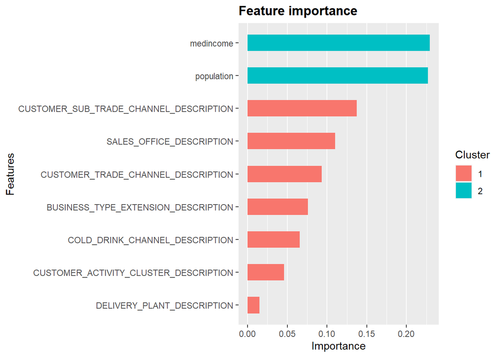

```r
# plot
gp = xgb.ggplot.importance(importance_matrix)
print(gp)
```

As the model is performing better than random guessing, we would suggest swire to use the model and continues to optimize the model by adding more outside data such as social economic data like median income and population. Out of the 10 variables that we have used for the model, median income, population, and customer trade channels were the most important predictors. It indicates that the current customer data does not have much impact in predicting the customer tiers, and we may need more outside data to help improve the predicting power.

# Recommendations

One of the ways Swire could leverage our current model is to classify each potential customer using the features we previously mentioned. For each tier, we recommend establishing guidelines for the maximum and minimum discounts that sales teams can offer. Since A and B tier customers are more likely to generate more revenue, Swire should be willing to offer greater discounts to secure these businesses. Conversely, there should be a maximum discount level for C and D tier customers given their decreased likelihood of generating successful revenue.

# Next step